# Supplemental Digital Content

Reproductive Services Offered by Restorative Reproductive Medicine Practices: A National Secret-Shopper Audit

September 05, 2026

This supplement contains material referenced in the main text. It is generated from the same analysis outputs as the manuscript; no number here is independently recomputed.

## Appendix Table S1. Caller concentration and contrast separability

Each scenario arm was dominated by a different caller, so a scenario contrast is also a caller contrast. The second table shows which contrasts have any caller placing calls under both scenarios; a contrast with zero such callers cannot be separated from a caller effect by any adjustment.

Table S1a. Concentration of each scenario arm in a single caller.

[output not shown]

Table S1b. Caller overlap by contrast.

| Contrast | Callers placing both | Which callers | Calls contributed | Separable from caller? |
| --- | --- | --- | --- | --- |
| Straight couple vs Lesbian couple | 0 | none | 0 | No |
| Straight couple vs Single mother | 0 | none | 0 | No |
| Lesbian couple vs Single mother | 3 | Caller A, Caller C, Caller E | 59 | Partly |

Table S1c. Call volume and outcome rates by caller. Rates vary widely across callers, which is why a scenario arm dominated by one caller cannot be read as a scenario effect.

[output not shown]

## Appendix Table S2. Documentation completeness by caller scenario

Documentation completeness differed by arm in the same direction as the exploratory outcome. Because the derived availability outcome is read off the appointment date, a call recorded less completely is scored as less available regardless of what the practice said. Differential documentation and differential availability cannot be separated in these data.

Table S2. Documentation completeness by caller scenario.

| Scenario | Calls placed | No call date | Reached staff | No appointment date |
| --- | --- | --- | --- | --- |
| Straight couple | 77 | 6 (7.8%) | 39 | 11 (28.2%) |
| Lesbian couple | 83 | 19 (22.9%) | 37 | 23 (62.2%) |
| Single mother | 74 | 12 (16.2%) | 32 | 17 (53.1%) |

## Appendix Table S3. Reproductive services offered, numeric detail

Numeric detail underlying Figure 1, among the 98 calls that reached staff and completed the service interview. Intrauterine insemination and in vitro fertilization each rest on a single practice; those two intervals should be read as an upper bound on availability rather than as stable rates.

Table S3. Reproductive services offered (N = 98 calls reaching staff).

| Reproductive Service | Proportion Offered (95% CI) |
| --- | --- |
| Cycle tracking | 94.9% (95% CI 88.6-97.8%; 93/98) |
| Hormonal labs / fertility timing | 63.3% (95% CI 53.4-72.1%; 62/98) |
| Ovulation induction | 11.2% (95% CI 6.4-19.0%; 11/98) |
| Intrauterine insemination (IUI) | 1.0% (95% CI 0.2-5.6%; 1/98) |
| In vitro fertilization (IVF) | 1.0% (95% CI 0.2-5.6%; 1/98) |
| Works with donor sperm | 3.1% (95% CI 1.0-8.6%; 3/98) |

## Appendix Table S4. STROBE checklist for cross-sectional studies

Table S4. Completed STROBE checklist.

[output not shown]

## Appendix Table S5. Duplicate practice-scenario calls and their adjudication

The protocol specifies one call per practice per scenario. Eight cells contained two. Where a contact attempt (voicemail, wrong number, abandoned or over-long hold) preceded a completed call, the completed call determined the cell. Where two protocol-valid completed calls existed, the cell was treated as a protocol deviation and excluded from the primary paired analysis rather than resolved by preferring the earlier or later call. Practice identifiers are redacted.

Table S5a. All calls in a practice-scenario cell containing more than one call. Practices are identified by study ID only.

| Record ID | Practice ID | Scenario | Call date | Disposition | Analytic inclusion |
| --- | --- | --- | --- | --- | --- |
| 141 | 1 | Lesbian couple | NA | Went to voicemail | FALSE |
| 142 | 1 | Lesbian couple | NA | Went to voicemail | FALSE |
| 22 | 7 | Straight couple | 2026-06-01 | Number contacted did not correspond to expected office/specialty | FALSE |
| 30 | 7 | Straight couple | NA | Number contacted did not correspond to expected office/specialty | FALSE |
| 93 | 17 | Lesbian couple | 2026-06-01 | Greater than 5 minutes on hold | FALSE |
| 102 | 17 | Lesbian couple | 2026-06-02 | Went to voicemail | FALSE |
| 177 | 57 | Single mother | NA | Went to voicemail | FALSE |
| 179 | 57 | Single mother | 2026-06-30 | Included where physician was able to be contacted | TRUE |
| 126 | 65 | Lesbian couple | 2026-06-05 | Included where physician was able to be contacted | TRUE |
| 156 | 65 | Lesbian couple | NA | Included where physician was able to be contacted | TRUE |
| 164 | 67 | Straight couple | 2026-06-10 | Included where physician was able to be contacted | TRUE |
| 193 | 67 | Straight couple | 2026-06-30 | Included where physician was able to be contacted | TRUE |
| 37 | 97 | Straight couple | 2026-06-01 | Went to voicemail | FALSE |
| 198 | 97 | Straight couple | 2026-07-14 | Included where physician was able to be contacted | TRUE |
| 56 | 104 | Straight couple | 2026-06-01 | Greater than 5 minutes on hold | FALSE |
| 163 | 104 | Straight couple | 2026-06-05 | Went to voicemail | FALSE |

Table S5b. Cells with two protocol-valid completed calls. Practices are identified by study ID only.

| Practice ID | Scenario | Completed calls | Disposition |
| --- | --- | --- | --- |
| 65 | Lesbian couple | 2 | Excluded from the primary paired analysis as a protocol deviation |
| 67 | Straight couple | 2 | Excluded from the primary paired analysis as a protocol deviation |

## Appendix Table S7. Caller variance components

The proportion of outcome variance lying between callers rather than within them, from a one-way variance-components model. A scenario arm dominated by a single caller cannot be read as a scenario effect when this much of the variation tracks who placed the call. Method follows the sibling urogynecology mystery-caller study (mufflyt/lizeth, `caller_icc.R`), which reached the same fallback: a paired inter-caller ICC is not estimable with so few practices called by two callers, so a variance-components ICC is used instead.

Table S7. Proportion of outcome variance attributable to the caller.

| Outcome | ICC | Callers | Calls |
| --- | --- | --- | --- |
| Business-day wait | 0.36 | 5 | 56 |
| Inferred appointment availability | 0.31 | 6 | 99 |
| Reached a live office | 0.29 | 6 | 233 |

## Appendix Table S8. What the paired intervals exclude

A minimum detectable effect states what the design could have found. This states what the data actually rule out, on the percentage-point scale. The upper limit of each interval is the largest disadvantage compatible with these data. Presentation follows mufflyt/lizeth, `null_verification.R`: “the upper CI is the LARGEST delay compatible with our data.”

Table S8. Paired differences in inferred appointment availability, with the range of effects the data are compatible with.

| Contrast | Paired practices | Discordant | Difference (pp) | 95% CI (pp) |
| --- | --- | --- | --- | --- |
| Straight couple vs Single mother | 16 | 7 | +31.2 | -6.9 to +43.4 |
| Lesbian couple vs Single mother | 22 | 2 | -9.1 | -9.1 to +6.2 |
| Straight couple vs Lesbian couple | 19 | 8 | +42.1 | +11.0 to +42.1 |

## Appendix Table S6. Restriction checkbox, why it is excluded

The instrument’s three “restrictions to the individuals you would provide care to” checkboxes are excluded from every analysis. The codebook defines a ticked box as a restriction applying to that group, with no field note or branching logic, but the recorded responses follow two incompatible conventions keyed to the person completing the form. One caller ticked all three boxes on most of her entries, which under the codebook definition would mean those practices serve no one. Every other caller ticked only the box matching the scenario they called as, which echoes the assignment rather than describing the practice. Because the convention belongs to the caller rather than the response, and a quarter of calls record no caller, no recoding rule can separate them.

Table S6. Combination of restriction boxes ticked, by person completing the form.

| Caller | Boxes ticked | Calls |
| --- | --- | --- |
| Caller C | Lesbian + Straight + SingleMother | 19 |
| Caller F | Straight | 9 |
| Caller D | Straight | 4 |
| Caller A | Lesbian | 3 |
| Caller C | Straight | 3 |
| Caller C | Lesbian + Straight | 2 |
| Caller E | Lesbian | 2 |
| Unrecorded | Lesbian | 1 |

## Appendix Figure S1. Wait time to first available appointment

Restricted to the 57 calls with an observed appointment date. Panels are a raincloud plot, a ridgeline density, the empirical cumulative distribution, and within-practice paired differences. These estimates condition on having been offered an appointment and are descriptive; see Limitation 5 in the main text.

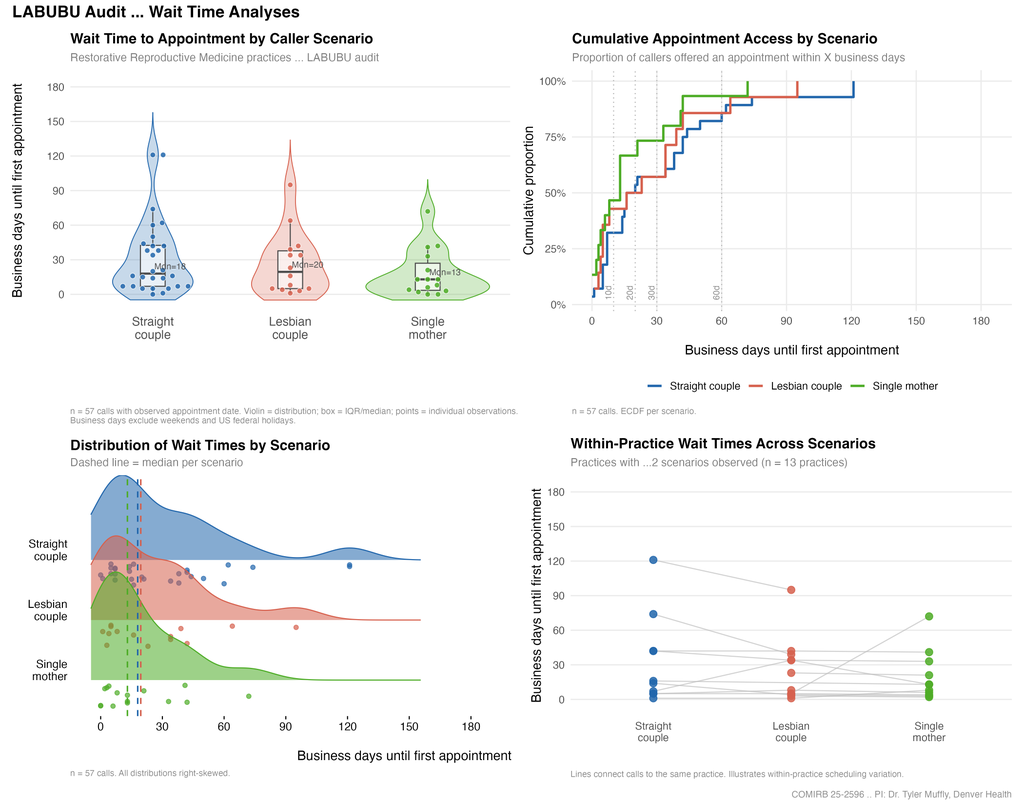

Figure S1. Wait time to first available appointment by caller scenario.

Generated 2026-09-05 18:11 MDT from commit `3140b00`.